# Topic 15

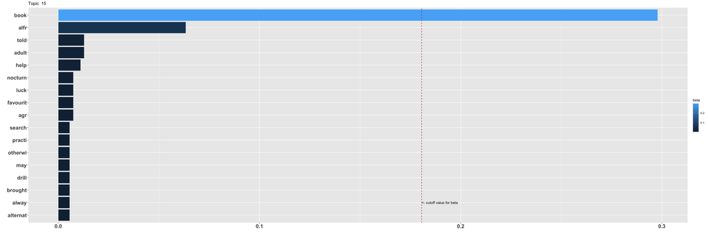

On interpreting beta: the term has a beta probability of being generated from the particular topic.

Values below are gamma : An estimated proportion of words from that document that are generated from that topic.

**Text Record Number: 581** gamma: 15 % likelihood of this document (based on its words) in this topic

**I’ve been learning for 2-3 months now. I bought a few books but the one that helped me at first was kids book, playing nursery rhymes! One of the books I bought I have found pretty useless because it was theory and practise drills and zero fun!

The next book I have is Easy Piano songs for beginners which I am working my way through

I’ve been learning for 2-3 months now. I bought a few books but the one that helped me at first was a kids book, playing nursery rhymes! One of the books I bought I have found pretty useless because it was theory and practise drills and zero fun!

I can play Amazing Grace, Let it Be, Silent Night, All Things Bright and Beautiful and some others so far

I get a sense of achievement and satisfaction once I can play a song without errors

Maybe not the most advanced method of learning but this is the way that has worked for me (so far). I don’t like being on a course I like t do my own thing so I buy a few books and find some songs that are not too difficult but not too easy and then try to advance like that**

**Text Record Number: 1246** gamma: 15 % likelihood of this document (based on its words) in this topic

**I played piano for a few years when I was younger. I’m coming back to it now almost 20 years later and want to take it more seriously. My current level of playing is around RCM4 or 5 (the same level as I was back when I stopped being formally taught). I’ve been getting back into it for a few months now and although my playing is better, I feel like I’m really lacking at music theory.

I’m looking into theory books but I’ve accidentally ended up with books that start from zero (how to read notes) to books that are really deep in the weeds and I don’t understand what’s going on (I’m really rusty on some of the more intermediate topics).

I no longer have my old theory books either. Anyone have book recommendations on a good place to return to theory based on my level? It’d be greatly appreciated!**

**Text Record Number: 449** gamma: 15 % likelihood of this document (based on its words) in this topic

**I’m currently running through the first adult all in one book from Alfred. Great book! Currently learning about harmonic intervals and very simple sight reading. This might be too simple for your knowledge level. I’d say buy book 1 first and run through the whole series, but you might be bored with the content of the first book**

**Text Record Number: 1248** gamma: 15 % likelihood of this document (based on its words) in this topic

**I am getting back into piano and loving it. I played it for a few years when I was a kid but was really undisciplined and never got very far. This year, I’m getting back into it (almost 20 years later!) and I still remember the basics like reading notes, sharps/flats, dynamics etc. and can play pieces up to RSM 4 or 5 (not very well though lol). To improve, I want to get more into music theory. A lot of books I’ve been buying either start from 0 (ie. This is the what middle C looks like!) or are kind of advanced. And it’s hard to see what you’re going to get because they don’t have previews or even table of contents online for a lot of the books.

Anyone have good recommendations based on books they’ve used themselves or suggested to students?

Thanks!**

**Text Record Number: 1383** gamma: 15 % likelihood of this document (based on its words) in this topic

**Hey there,

I started learning piano back in february, made it a little through Alfred’s and then decided on a teacher (only been via zoom so far).

The teaching schedule has looked like this so far:

March:

- Focusing on very simple nursery rhymed and drilling in the FACE/ACEG and how to read the music

April:

- Tackling 1-14 in the Czerny books, following the exact (rather strange and annoying) fingerings (I found this really tough. I hated it but pushed through!

May:

- Bach’s Magdalena book. Focused on learning Minuet in G. This took about 3 weeks practicing an hour a day

June:

- Bach book again, this time learning some other ‘Menuets’ - similar in difficulty. I could do these in around 2 weeks

July:

- Managed to finish a Bach piece (Menuet 132) in 7 days, practicing roughly about 12 hours. I can play with no mistakes.

&#x200B;

My worry is that I see a lot of advice on here saying that you shouldn’t be learning songs that you cannot sightread with both hands at (the very least) a low, low tempo. I can do hands apart (with a few mistakes) but DEFINITELY could NOT do these pieces hands together at sight.

So far my teacher has been breaking the pieces into ‘cognitive units’ - telling me to learn them in 4 bar chunks. Right hand first, then left. However, from what I read on here, if it’s taking hours upon hours to learn and perfect, then the piece is probably too hard?

Sure, once it’s in muscle memory, I can play it just fine, but on sight? It’s a different story. I’m worried that perhaps my teacher is pushing me a little too hard? I asked him about this and he said:

“You don’t have to worry - these pieces are hard. Next week we can look at a piece to consolidate your reading. I’d actually prefer you to learn these pieces the way you have been, your progress is perfect. Yes, you’ve done 4 pieces so far, but by the time you’ve learned the 12 I plan the reading aspect will begin to sink in and then we can just work on brushing all the pieces up”

Earlier on, he also said (when I asked about the fact that I’m forgetting the other pieces with each successive one that I learn)

“Cognitively you’ve forgotten it, but it’s in your muslce memory and the nurones have been created! In the future, that’s how you practice sight reading, by reactivating the neurones”

I really like him as a teacher and it’s very clear that I’ve made huge leaps in terms of my ability since getting a teacher, but I’m worried that my sight-reading is completely suckish.**

**Text Record Number: 330** gamma: 15 % likelihood of this document (based on its words) in this topic

**Haha just my luck.

Generally American books will refer to measures, quarter notes, whole notes etc. British books will talk about bars and crotchets, semibreves etc. It’s just worth finding a book that writes the way you’re familiar with.

I just wondered what you currently work on. You mentioned you didn’t attend a lot of classes this year so I wasn’t sure if you were looking for a level 1 method book or if you’ve been playing a while and need something more challenging.**

**Text Record Number: 398** gamma: 15 % likelihood of this document (based on its words) in this topic

**im using this:

https://www.amazon.com.au/dp/1875726268/ref=cm_sw_r_cp_api_glt_fabc_469PMVQX28NE8FN3VCTC

Its like Alfred book but with less details and better for the eyes of a beginner. Less stressful.

I do own alfreds book aswell but after the first few days with both, i decided to stick with piano method 1**